# 611_Final

2026-11-19

# Prepare df

```r
payroll <- payroll %>%
  mutate(
    `Fiscal Year` = as.integer(`Fiscal Year`),
    `Base Salary` = as.numeric(`Base Salary`),
    `Regular Gross Paid` = as.numeric(`Regular Gross Paid`),
    `Total OT Paid` = as.numeric(`Total OT Paid`),
    `Total Other Pay` = as.numeric(`Total Other Pay`),
    `Agency Name` = toupper(trimws(`Agency Name`))
  ) %>%
  filter(`Fiscal Year` %in% 2015:2020)
```

# Cols of the df

Base salary: Base Salary assigned to the employee

Regular Gross Paid: The amount paid to the employee for base salary during the fiscal year

OT Hours: Overtime Hours worked by employee in the fiscal year

Total OT Paid: Total overtime pay paid to the employee in the fiscal year

Total Other Pay: Includes any compensation in addition to gross salary and overtime pay, ie Differentials, lump sums, uniform allowance, meal allowance, retroactive pay increases, settlement amounts, and bonus pay, if applicable.

# Payroll spending and median salary (2015–2020)

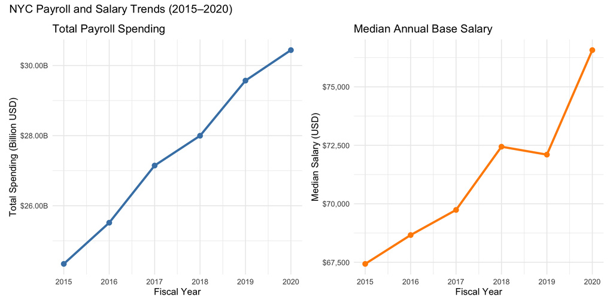

```r
fig1_data <- payroll %>%
  mutate(
    total_pay = coalesce(`Regular Gross Paid`, 0) +
                coalesce(`Total OT Paid`, 0) +
                coalesce(`Total Other Pay`, 0)
  ) %>%
  group_by(`Fiscal Year`) %>%
  summarise(
    total_spending = sum(total_pay, na.rm = TRUE),
    .groups = "drop"
  )

fig1_salary <- payroll %>%
  filter(
    grepl("annual|annum", `Pay Basis`, ignore.case = TRUE),
    `Base Salary` > 0,
    !is.na(`Base Salary`)
  ) %>%
  group_by(`Fiscal Year`) %>%
  summarise(
    median_salary = median(`Base Salary`),
    .groups = "drop"
  )

p1 <- ggplot(fig1_data,
             aes(x = `Fiscal Year`, y = total_spending)) +
  geom_line(color = "steelblue", linewidth = 1.2) +
  geom_point(color = "steelblue", size = 2.5) +
  scale_x_continuous(breaks = 2015:2020) +
  scale_y_continuous(
    labels = label_dollar(scale = 1e-9, suffix = "B")
  ) +
  labs(
    title = "Total Payroll Spending",
    x = "Fiscal Year",
    y = "Total Spending (Billion USD)"
  ) +
  theme_minimal()

p2 <- ggplot(fig1_salary,
             aes(x = `Fiscal Year`, y = median_salary)) +
  geom_line(color = "darkorange", linewidth = 1.2) +
  geom_point(color = "darkorange", size = 2.5) +
  scale_x_continuous(breaks = 2015:2020) +
  scale_y_continuous(labels = label_dollar()) +
  labs(
    title = "Median Annual Base Salary",
    x = "Fiscal Year",
    y = "Median Salary (USD)"
  ) +
  theme_minimal()

p1 + p2 +
  plot_annotation(
    title = "NYC Payroll and Salary Trends (2015–2020)"
  )
```

Both total payroll spending and median annual base salary generally increased between 2015 and 2020. Total payroll spending rose steadily from approximately $24.4 billion in 2015 to $30.4 billion in 2020. Meanwhile, median annual base salary increased from approximately $67,500 to $76,600, with a particularly noticeable increase between 2019 and 2020. These findings suggest that NYC experienced growth in both overall payroll expenditures and typical employee salaries during this period, although changes in workforce size and composition may also contribute to these trends.